# Time Series Analysis - Fina Exam - May 2022

Juan Garbayo - Time Series Analysis

May - 27th - 2022

```r
cafes <- aus_retail %>%
  filter(`Series ID` == "A3349849A")

cafes
```

```
## # A tsibble: 441 x 5 [1M]
## # Key:       State, Industry [1]
##    State                        Industry           `Series ID`    Month Turnover
##    <chr>                        <chr>              <chr>          <mth>    <dbl>
##  1 Australian Capital Territory Cafes, restaurant~ A3349849A   1982 Apr      4.4
##  2 Australian Capital Territory Cafes, restaurant~ A3349849A   1982 May      3.4
##  3 Australian Capital Territory Cafes, restaurant~ A3349849A   1982 Jun      3.6
##  4 Australian Capital Territory Cafes, restaurant~ A3349849A   1982 Jul      4
##  5 Australian Capital Territory Cafes, restaurant~ A3349849A   1982 Aug      3.6
##  6 Australian Capital Territory Cafes, restaurant~ A3349849A   1982 Sep      4.2
##  7 Australian Capital Territory Cafes, restaurant~ A3349849A   1982 Oct      4.8
##  8 Australian Capital Territory Cafes, restaurant~ A3349849A   1982 Nov      5.4
##  9 Australian Capital Territory Cafes, restaurant~ A3349849A   1982 Dec      6.9
## 10 Australian Capital Territory Cafes, restaurant~ A3349849A   1983 Jan      3.8
## # ... with 431 more rows
```

### 1. (**0.5 points**) Create a time-plot of the series adjusting the grid so that it signals the beginning of every year.

```
## Plot variable not specified, automatically selected `.vars = Turnover`
```

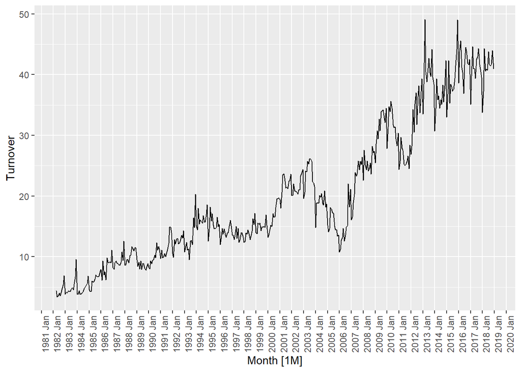

```r
#SOLUTION
autoplot(cafes) +
scale_x_yearmonth(date_breaks = "1 year",
                  date_minor_breaks = "1 year") +
# Flip x-labels by 90 degrees
theme(axis.text.x = element_text(angle = 90))
```

Answer briefly (max 50 words):

- Does the scheme look purely additive or multiplicative to some extent?

### 2. (**1.5 points**) Perform an STL decomposition of the time series. Adjust the arguments of the decomposition so that the remainder component is smaller than the seasonal component. Remember that to apply the STL decomposition certain conditions need to be fulfilled, so you may need to manipulate the time series.

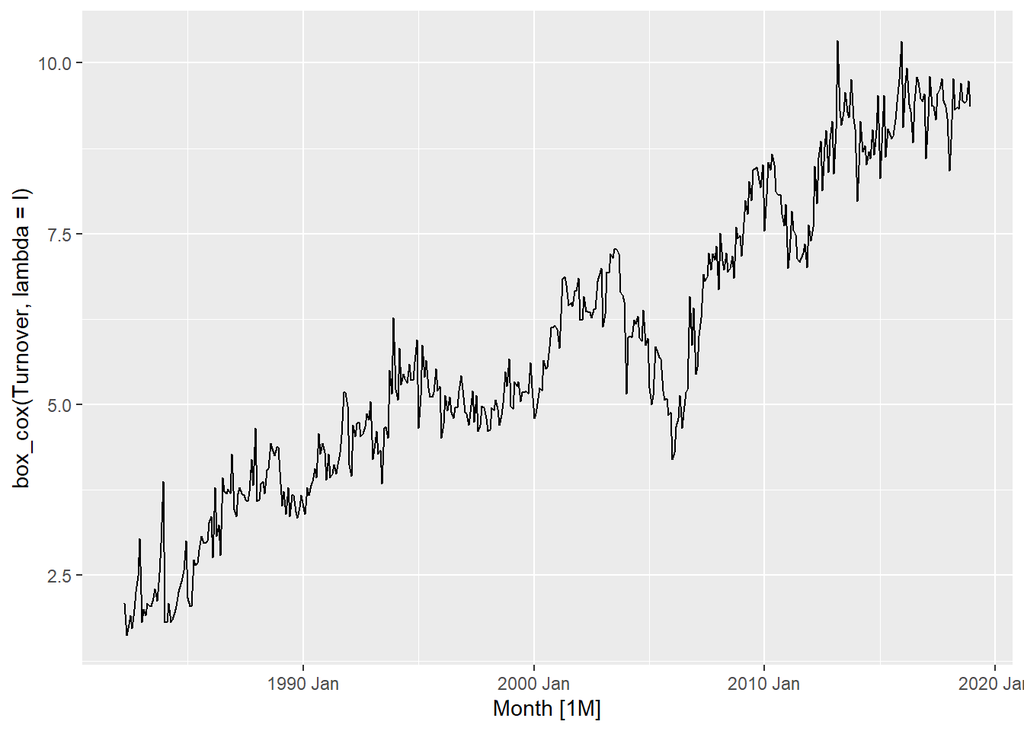

```r
#SOLUTION
# Obtain the suggested value for lambda
l <- cafes %>%
  features(Turnover, features = guerrero) %>%
  pull(lambda_guerrero)

# Inspect the transformed series
cafes %>%
  autoplot(box_cox(Turnover, lambda = l))
```

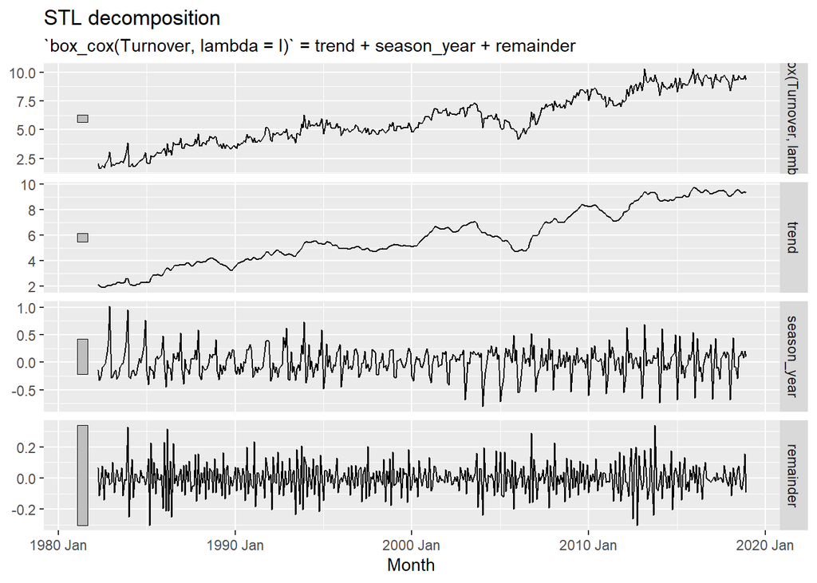

```r
# Perform the decomposition
dcmp <-cafes %>%
        model(
          STL(box_cox(Turnover, lambda = l) ~ trend(window = 5) + season(window=5))
        ) %>%
        components()

# Depict the decomposition
dcmp %>% autoplot()
```

### 3. (**1 point**) Obtain the autocorrelation graph of:

- The total time series.
- The seasonally adjusted component.
- The seasonal component of the time series.

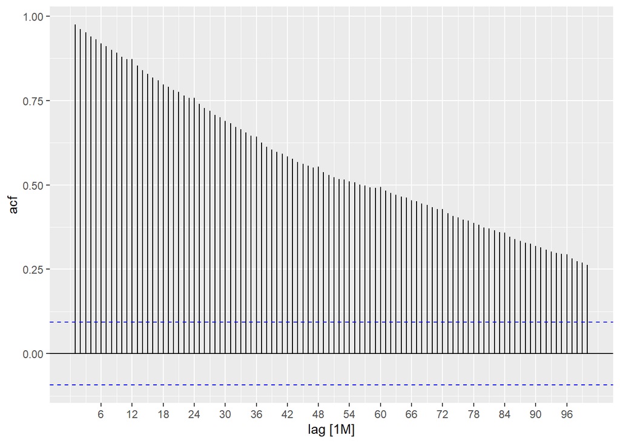

```r
#SOLUTION
dcmp <-cafes %>%
        model(
          STL(box_cox(Turnover, lambda = l) ~ trend(window = 5) + season(window=5))
        ) %>%
        components()

# dcmp %>% autoplot()
cafes %>% ACF(box_cox(Turnover, lambda = l), lag_max = 100) %>% autoplot()
```

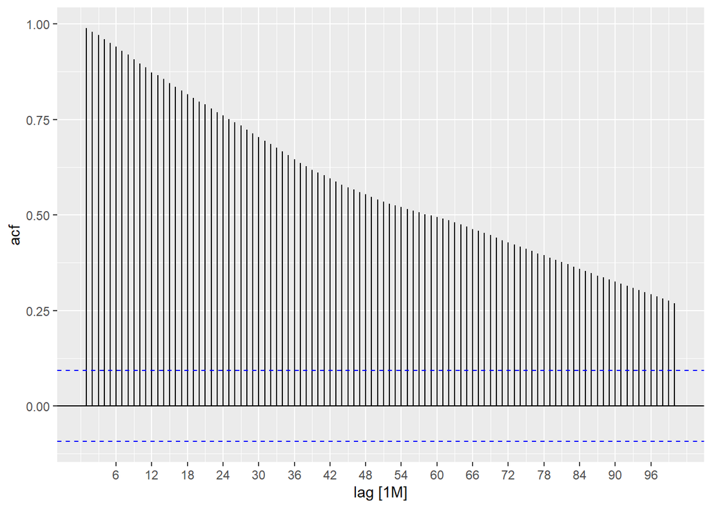

```r
dcmp %>% ACF(season_adjust, lag_max = 100) %>% autoplot()
```

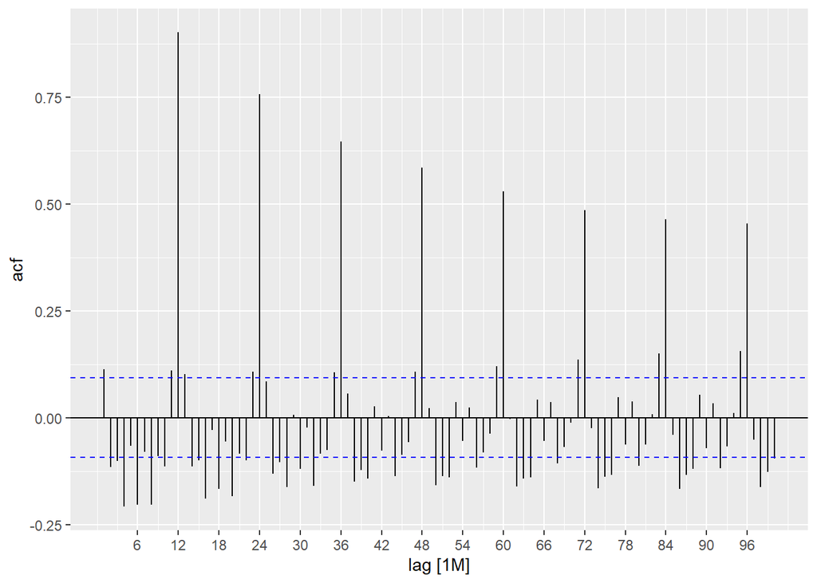

```r
dcmp %>% ACF(season_year, lag_max = 100) %>% autoplot()
```

Answer briefly (max 75 words per question. You may use less than 75 words as well).

- Compare the autocorrelation graph of the total time series and the seasonally-adjusted series.
  - Are they similar to one another? Why? Why not?

Both graphs are very similar. This is due to the fact that the seasonal component is much smaller than the trend component. The seasonally-adjusted component (remainder + trend) is therefore not much different from the total time series.

- Does the series exhibit seasonality? **Focus on the values of the autocorrelation on multiples of the seasonal period**.
  - If so, in which graph did you spot the seasonality?

Examining the autocorrelation graph of the seasonal component, we see that the series exhibits yearly seasonality. This can be recognized in the spikes at lags 12, 24, 36… (multiples of 12) on the seasonal component.

### 4. (**0.5 points**) Obtain two train sets containing 60 and 80% of the data.

```r
#SOLUTION
rows_80 <- floor(nrow(cafes)*0.8)
rows_60 <- floor(nrow(cafes)*0.6)

train_60 <- cafes %>% slice(1:rows_60)
train_80 <- cafes %>% slice(1:rows_80)
```

### 5. (**1 point**) Fit the following models to each of the training datasets:

- Naive model
- Simple Exponential Smoothing
- Mean model
- Seasonal Naive model
- `decompositoin_model()` with:
  - STL decomposition applied to decompose the time series.
    - Note: if you managed to find good parameters for the decomposition in question 2, use those. Otherwise use the defaults.
  - Drift model applied to the seasonally adjusted component.
  - SNaive model applied to the seasonal component.

```r
#SOLUTION
fit_tr60 <- train_60 %>%
              model(
                naive_60 = NAIVE(Turnover),
                SES_60 = ETS(Turnover ~ error("A") + trend("N") + season("N")),
                mean_60 = MEAN(Turnover),
                snaive_60 = SNAIVE(Turnover),
                decomp_stl_60 = decomposition_model(
                             # Specify decomposition scheme to be used
                             STL(box_cox(Turnover, lambda = l) ~ trend(window = 5) + season(window=5)),
                             # Specify model for the seasonally adjusted component
                             RW(season_adjust ~ drift()),
                             # Specify model for the seasonal component (unnecessary since SNAIVE is default)
                             SNAIVE(season_year)
                             )
              )

fit_tr80 <- train_80 %>%
              model(
                naive_80 = NAIVE(Turnover),
                SES_80 = ETS(Turnover ~ error("A") + trend("N") + season("N")),
                mean_80 = MEAN(Turnover),
                snaive_80 = SNAIVE(Turnover),
                decomp_stl_80 = decomposition_model(
                             # Specify decomposition scheme to be used
                             STL(box_cox(Turnover, lambda = l) ~ trend(window = 5) + season(window=5)),
                             # Specify model for the seasonally adjusted component
                             RW(season_adjust ~ drift()),
                             # Specify model for the seasonal component (unnecessary since SNAIVE is default)
                             SNAIVE(season_year)
                             )
              )

# Bind all the models in av single mable to handle forecasts more easily.
fit <- bind_cols(
  fit_tr60 %>% select(-c(State, Industry)), # Exclude column symbol to be able to bind columns
  fit_tr80 %>% select(-c(State, Industry))
)
```

### 6. (**1 point**) Evaluate the residuals accuracy for the different models **on the training dataset** using the corresponding training dataset and the function `accuracy()`. Keep the `MAE`, `RMSE` and `MAPE` errors:

```r
#SOLUTUION
fit %>%
  accuracy() %>%
  select(.model, .type, MAE, RMSE, MAPE, MASE, RMSSE) %>%
  arrange(RMSE)
```

```
## # A tibble: 10 x 7
##    .model        .type      MAE  RMSE  MAPE  MASE RMSSE
##    <chr>         <chr>    <dbl> <dbl> <dbl> <dbl> <dbl>
##  1 decomp_stl_60 Training 0.728 0.977  6.18 0.393 0.404
##  2 decomp_stl_80 Training 0.818 1.09   5.84 0.314 0.315
##  3 SES_60        Training 1.05  1.48   9.47 0.567 0.613
##  4 naive_60      Training 1.10  1.61   9.89 0.592 0.666
##  5 SES_80        Training 1.20  1.68   8.99 0.463 0.485
##  6 naive_80      Training 1.27  1.82   9.41 0.488 0.525
##  7 snaive_60     Training 1.85  2.42  14.4  1     1
##  8 snaive_80     Training 2.60  3.47  16.2  1     1
##  9 mean_60       Training 4.39  5.46  49.4  2.37  2.26
## 10 mean_80       Training 5.92  7.46  56.5  2.27  2.15
```

### 7. (**1 point**) Answer the following questions regarding the output of question 6

Questions (answer briefly, max 75 words per question but be as succint as possible):

- What is the forecast horizon of the residuals for which the metrics have been computed in 6?

The metrics have been computed based on the residuals. Residuals are one-step ahead forecasts computed on the training dataset. Therefore we could say that the above metrics are based on a one-step horizon.

- What are the units of the MAE? What does it represent?

The units of the Mean Absolute Error are the same as the units of the time series. In this case $Million AUD.

As its name indicates it is simply the mean of the absolute errors of the forecasts.

- What are the units of the RMSE?

The units of the Root Mean Squared Error are the same as the units of the time series. In this case, again $Million AUD.

Instead of taking the absolute value as in the MAE, the RMSE works with the squared errors to ensure positive and negative errors do not cancel each other out when averaging. After avering these errors, taking the square root yields the RMSE.

- What are the units of MAPE? What does it represent?

The Mean Absolute Percentage Error has no units. It is the mean of the percentage errors, which are unitless because the units in the numerator and the denominator cancel each other out:

$$p_{t} = 100 e_{t}/y_{t}$$

Being unitless these error metrics may be used to compare the performance of forecast methods between different datasets.

- Which is the best performing model in terms of RMSE? Clarify how you have determined this.

Based on the metrics performed on the training dataset (based on the residuals), the best performing model is `decomp_stl_60`. This may be seen on the table above, where it is clear that this model has the smallest RMSE.

- For a given error metric and model type (naive, decomposition, SES…), do the results change with the training dataset? Why or why not?

Yes. We may see this by comparing the metrics of each model on the training dataset containing 60 and 80 percent of the observations. * The main reason for this is that the time series itself might be behaving different at each cut-out point. * The second reason is the different manner in which the model fits each dataset. In this case the models have so little parameters (or even no parameters) that this is not the likely cause.

### 8. (**0.5 points**) For the best model in terms of RMSE of the residuals, assess and interpret the autocorrelation of the residuals (max 75 words but be as succint as possible).

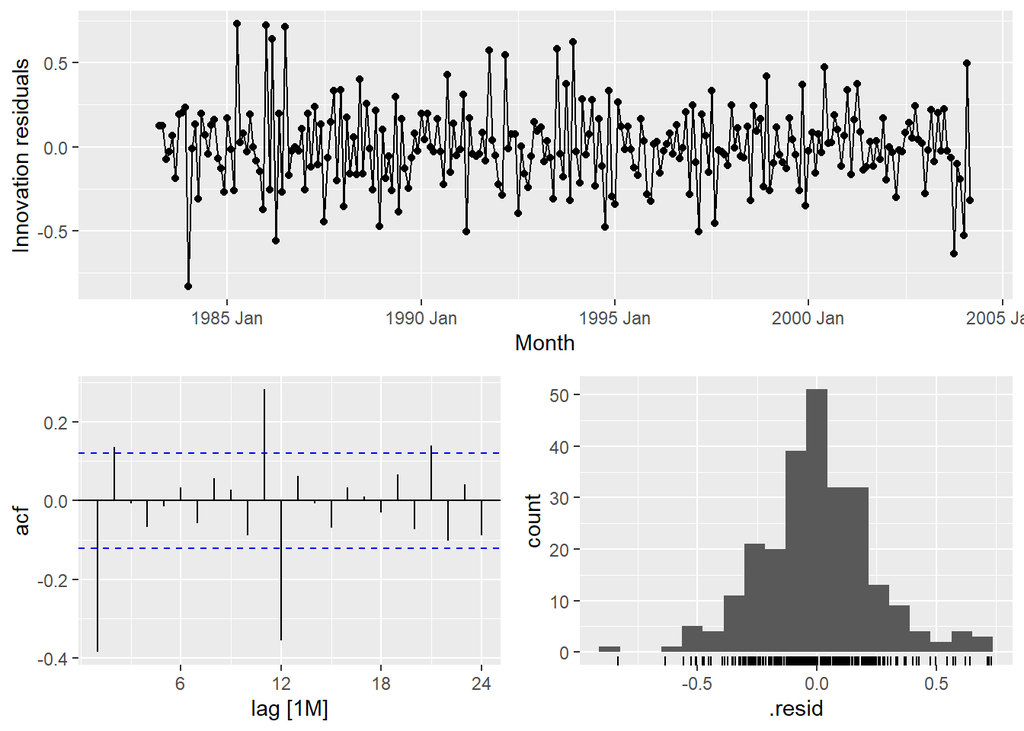

```r
#SOLUTION
fit %>%
  select(decomp_stl_60) %>% # Selects the best model in terms of RMSE
  gg_tsresiduals()
```

```r
# Box-Pierce Statistic
fit %>%
  select(decomp_stl_60) %>% # Selects the best model in terms of RMSE
  augment() %>%
  features(.innov, box_pierce, lag = 24, dof = 1)
```

```
## # A tibble: 1 x 3
##   .model        bp_stat bp_pvalue
##   <chr>           <dbl>     <dbl>
## 1 decomp_stl_60    114.  4.70e-14
```

Desipte `decomp_60` being the model that behaves best in terms of the RMSE of its residuals, its residuals actually exhibit signs of autocorrelation. This means that there is information left in the residuals that `decomp_60` does not account for, and therefore we can positively say that the model is improvable.

On the other hand, if a model does not show autocorrelation in its residuals, it does not mean that it cannot be improved.

### 9. (**1.5 points**) For every model fitted in 5, generate forecasts of up to 1 seasonal period. Then evaluate the errors of those forecasts (i.e. compare the forecasts to the actual values of the test datasets using the `accuracy()` function). The output should return the error metrics for each model and forecast horizon.

```r
#SOLUTION
fc <- fit %>%
        forecast(h = 12)

fc <- fc %>%
        group_by(.model) %>%
        mutate(h = row_number()) %>%
        ungroup() %>%
        as_fable(response = "Turnover", distribution = Turnover)

summary <- fc %>%
              accuracy(cafes, by=c("h", ".model"))
```

[output not shown]

[output cut: 304 more lines]

[output not shown]

```r
summary
```

```
## # A tibble: 120 x 11
##        h .model   .type      ME   RMSE    MAE     MPE   MAPE   MASE  RMSSE  ACF1
##    <int> <chr>    <chr>   <dbl>  <dbl>  <dbl>   <dbl>  <dbl>  <dbl>  <dbl> <dbl>
##  1     1 decomp_~ Test  -0.529  0.529  0.529   -2.82   2.82  0.286  0.219     NA
##  2     1 decomp_~ Test  -0.254  0.254  0.254   -1.00   1.00  0.0974 0.0731    NA
##  3     1 mean_60  Test   6.13   6.13   6.13    32.6   32.6   3.31   2.54      NA
##  4     1 mean_80  Test   9.94   9.94   9.94    39.3   39.3   3.82   2.87      NA
##  5     1 naive_60 Test  -0.100  0.100  0.100   -0.532  0.532 0.0540 0.0414    NA
##  6     1 naive_80 Test   0.300  0.300  0.300    1.19   1.19  0.115  0.0865    NA
##  7     1 SES_60   Test   0.0700 0.0700 0.0700   0.373  0.373 0.0378 0.0290    NA
##  8     1 SES_80   Test  -0.244  0.244  0.244   -0.963  0.963 0.0936 0.0703    NA
##  9     1 snaive_~ Test  -5.2    5.2    5.2    -27.7   27.7   2.81   2.15      NA
## 10     1 snaive_~ Test  -6      6      6      -23.7   23.7   2.31   1.73      NA
## # ... with 110 more rows
```

- For a forecast horizon of 1, which model performs best in terms of RMSE? Is it the same model that performed best when using only the training dataset? Why or why not?
  - NOTE: to answer this question you need to write a bit of code on the matrix containing the summary metrics

```r
#SOLUTION
summary %>%
  filter(h == 1) %>%
  arrange(RMSE)
```

```
## # A tibble: 10 x 11
##        h .model   .type      ME   RMSE    MAE     MPE   MAPE   MASE  RMSSE  ACF1
##    <int> <chr>    <chr>   <dbl>  <dbl>  <dbl>   <dbl>  <dbl>  <dbl>  <dbl> <dbl>
##  1     1 SES_60   Test   0.0700 0.0700 0.0700   0.373  0.373 0.0378 0.0290    NA
##  2     1 naive_60 Test  -0.100  0.100  0.100   -0.532  0.532 0.0540 0.0414    NA
##  3     1 SES_80   Test  -0.244  0.244  0.244   -0.963  0.963 0.0936 0.0703    NA
##  4     1 decomp_~ Test  -0.254  0.254  0.254   -1.00   1.00  0.0974 0.0731    NA
##  5     1 naive_80 Test   0.300  0.300  0.300    1.19   1.19  0.115  0.0865    NA
##  6     1 decomp_~ Test  -0.529  0.529  0.529   -2.82   2.82  0.286  0.219     NA
##  7     1 snaive_~ Test  -5.2    5.2    5.2    -27.7   27.7   2.81   2.15      NA
##  8     1 snaive_~ Test  -6      6      6      -23.7   23.7   2.31   1.73      NA
##  9     1 mean_60  Test   6.13   6.13   6.13    32.6   32.6   3.31   2.54      NA
## 10     1 mean_80  Test   9.94   9.94   9.94    39.3   39.3   3.82   2.87      NA
```

The best performing model in terms of RMSE for a forecast horizon of 1 seems to be exponential smoothing fitted to the 60% dataset. It is different from the model that performed best on the training dataset becase the fact that a model performs best on the training dataset does not mean it will perform best when exposed to new data (test dataset)

- For a forecast horizon equal to half the seasonal period, which model performs best in terms of RMSE?
  - NOTE: to answer this question you need to write a bit of code on the matrix containing the summary metrics

```r
#SOLUTION
summary %>%
  filter(h == 6) %>%
  arrange(RMSE) %>%
  head(1)
```

```
## # A tibble: 1 x 11
##       h .model .type     ME  RMSE   MAE   MPE  MAPE  MASE  RMSSE  ACF1
##   <int> <chr>  <chr>  <dbl> <dbl> <dbl> <dbl> <dbl> <dbl>  <dbl> <dbl>
## 1     6 SES_60 Test  -0.230 0.230 0.230 -1.24  1.24 0.119 0.0909    NA
```

- For a forecast horizon equal to the seasonal period, which model performs best in terms of RMSE?
  - NOTE: to answer this question you need to write a bit of code on the matrix containing the summary metrics

```r
#SOLUTION
summary %>%
  filter(h == 12) %>%
  arrange(RMSE) %>%
  head(1)
```

```
## # A tibble: 1 x 11
##       h .model  .type    ME  RMSE   MAE   MPE  MAPE  MASE RMSSE  ACF1
##   <int> <chr>   <chr> <dbl> <dbl> <dbl> <dbl> <dbl> <dbl> <dbl> <dbl>
## 1    12 mean_60 Test   2.03  2.03  2.03  13.8  13.8  1.03 0.789    NA
```

### 10. (**1.5 points**) Instead of fitting the models to just two datasets, perform cross-validation using `stretch_tsibble()` to generate all the training datasets

- The smallest training dataset shall contain 60% of the observations.
- The training datasets shall increase in steps of 5 observations.
- The goal is to **obtain summary metrics for each model type and forecast horizon**. Retain the `MAE`, the `RMSE` and the `MAPE`.
  - Arrange your results from smallest to largest RMSE

After you have performed the computations, some questions follow:

```r
#SOLUTION
cafes_cv <- cafes %>%
  stretch_tsibble(.init = trunc(0.6*nrow(cafes)), .step = 5)

fit_cv <- cafes_cv %>%
              model(
                naive = NAIVE(Turnover),
                SES = ETS(Turnover ~ error("A") + trend("N") + season("N")),
                mean = MEAN(Turnover),
                snaive = SNAIVE(Turnover),
                decomp_stl = decomposition_model(
                             # Specify decomposition scheme to be used
                             STL(box_cox(Turnover, lambda = l) ~ trend(window = 5) + season(window=5)),
                             # Specify model for the seasonally adjusted component
                             RW(season_adjust ~ drift()),
                             # Specify model for the seasonal component (unnecessary since SNAIVE is default)
                             SNAIVE(season_year)
                             )
              )

fc_cv <- fit_cv %>%
            forecast(h = 12) %>%
            group_by(.id, .model) %>%
            mutate(h = row_number()) %>%
            ungroup() %>%
            as_fable(response = "Turnover", distribution = Turnover)

summary_cv <- fc_cv %>%
                accuracy(cafes, by=c("h", ".model")) %>%
                select(-c(MPE, MASE, RMSSE, ACF1, ME)) %>%
                arrange(RMSE)
bind_rows(
            summary_cv %>% filter(h == 1),
            summary_cv %>% filter(h == 6),
            summary_cv %>% filter(h == 12)
          )
```

```
## # A tibble: 15 x 6
##        h .model     .type  RMSE   MAE  MAPE
##    <int> <chr>      <chr> <dbl> <dbl> <dbl>
##  1     1 decomp_stl Test   2.28  1.84  6.37
##  2     1 SES        Test   3.03  2.21  7.43
##  3     1 naive      Test   3.12  2.42  7.86
##  4     1 snaive     Test   5.13  4.25 16.3
##  5     1 mean       Test  17.2  15.4  45.8
##  6     6 decomp_stl Test   4.34  3.69 12.9
##  7     6 SES        Test   4.47  3.29 11.5
##  8     6 naive      Test   4.63  3.54 12.3
##  9     6 snaive     Test   5.13  4.23 16.0
## 10     6 mean       Test  17.6  15.9  46.8
## 11    12 naive      Test   5.66  4.54 17.0
## 12    12 snaive     Test   5.66  4.54 17.0
## 13    12 decomp_stl Test   5.68  4.70 18.0
## 14    12 SES        Test   5.75  4.69 17.9
## 15    12 mean       Test  17.8  16.1  47.3
```

NOTE: to answer these quesitons you might need to filter and or arrange the output of the accuracy() function from your previous answer:

- **For a forecast horizon of 1**:
  - Which is the model with smallest RMSE?

The model that performs best in terms of RMSE for `h=1` seems to be the decomposition model.

- Is it the same model type than in question 9?

No, in the foregoing question the best performing model for h=1 was simple exponential smoothing.

- If they differ, why do they?

They differ because question 9 assessed the performance of the different models over two particular datasets. This makes the results susceptible to behavior differences in the time series at each cut-out point of the training dataset or to differences in the manner the model fits each dataset. Given the low number of parameters of these models, the latter is not the primary factor influencing these differences.

Cross-validation is more statistically robust and assesses the performance over a series of datasets, returning the average performance.

- **For a forecast horizon of 6**:
  - Which is the model with smallest RMSE?

The model that performs best in terms of RMSE for `h=6` seems to be again the decomposition model.

- Is it the same model type than in question 9?

It is not the same model than in question 9. The reason is the same one given above.

- If they differ, why do they?

See above.

- **For a forecast horizon of 12**:
  - Which is the model with smallest RMSE?

For a forecast horizon of 12, the naive and snaive model perform best. Their performances match exactly because the seasonal naïve model extends the behavior of the latest period into the future while the naïve model extends the last value into the future. Therefore, for a forecast horizon equal to the seasonal period (or to an exact multiple of the seasonal period) their performances match.

- Is it the same model type than in question 9?

It is not the same model than in question 9. The reason is the same one given above.

- If they differ, why do they?

See above.